# 17.4. R6 Classes

`R6` is a newer package by Winston Chang that lets you do standard-style OOP. We define a class with private fields `symbol` and `data` and accessor and modifier functions.

I find that the main advantages of this package are:

1. It feels familiar to those who are coming to R from other OOP languages.
2. Simplicity. It is very easy to use and has therefore become quite popular
3. Documentation. The documentation is sufficiently detailed for novice users to get going

# 17.4.1. Class Definition

We will again continue with the same stock example.

```r
library(R6)
Stock <- R6Class("Stock",
                 private = list(symbol = NA,
                                data = NA),
                 public = list(
                     initialize = function(symbol, data) {
                         private$symbol <- symbol
                         private$data <- data
                     },
                     getSymbol = function() private$symbol,
                     setSymbol = function(symbol) private$symbol <- symbol,
                     getData = function() private$data,
                     setData = function(data) private$data <- data
                 )
                 )
```

This makes `Stock` an *object generator* function.

**Note** To avoid problems, I suggest using the same name for both the class and the generator function. For example, `Stock` above.

Also, note the use of `<-` rather than `<<-` in the `initialize`, `setSymbol` and `setData` methods.

The above class definition contains:

- Private fields. We can also have private methods, only visible to the class and its subclasses, but we don’t have private methods here
- Public methods. We can also have public fields, but we don’t define them for this class
- Initialization routine, the constructor if you wish.

Private fields (and methods) are accessed using the `private$` construct within the class definition. They are not accessible outside the class construction code except via public methods you expose.

Inside the class definition, you can refer to the public methods of the object using the `self$` construct. We’ll see examples below.

Here’s how we would use the stock `R6` class.

```r
s = Stock$new(symbol = "JUNK",
              data = data.frame(price = rnorm(10, mean = 100, sd = 5),
                                date = as.Date(Sys.Date()) - 1:10))
s
```

```
## <Stock>
##   Public:
##     clone: function (deep = FALSE)
##     getData: function ()
##     getSymbol: function ()
##     initialize: function (symbol, data)
##     setData: function (data)
##     setSymbol: function (symbol)
##   Private:
##     data: data.frame
##     symbol: JUNK
```

# 17.4.2. Print method

Maybe you want a better method for printing: you can define your own and maybe even have defaults. While we’re at it, let’s also define the validator method since we are providing field modifiers.

```r
Stock <- R6Class("Stock",
                 private = list(symbol = NA,
                                data = NA,
                                valid = function(symbol, data) {
                                    if (!is.data.frame(data)) {
                                        return(FALSE)
                                    }
                                    dfNames <- sort(names(data))
                                    expectedNames <- c("date", "price")
                                    if (length(expectedNames) != length(dfNames) ||
                                        !all.equal(expectedNames, dfNames)) {
                                        return(FALSE)
                                    }
                                    if ((!is.character(symbol)) || (length(symbol) != 1L) ||
                                        (nchar(symbol) == 0)) {
                                        return(FALSE)

                                    }
                                    TRUE
                                }),
                 public = list(
                     initialize = function(symbol = "JUNK",
                                           data = data.frame(price = rnorm(10, mean = 100, sd = 5),
                                                             date = as.Date(Sys.Date()) - 1:10)) {
                         if (!private$valid(symbol, data)) {
                             stop("Bad input values")
                         }
                         private$symbol <- symbol
                         private$data <- data
                     },
                     print = function() {
                         ## Have to use private$ for even our own private stuff
                         cat(sprintf("Stock Symbol: %s\n", private$symbol))
                         ## Have to use self$ for public stuff
                         str(self$getData())
                     },
                     getSymbol = function() private$symbol,
                     setSymbol = function(symbol) {
                         if (!private$valid(symbol, private$data)) {
                             stop("Bad symbol!")
                         }
                         private$symbol <- symbol
                     },
                     getData = function() private$data,
                     setData = function(data) {
                         if (!private$valid(private$symbol, data)) {
                             stop("Bad data!")
                         }
                         private$data <- data
                     }
                 )
                 )
```

Let’s give this a shot.

```r
s2 <- Stock$new()
s2
```

```
## Stock Symbol: JUNK
## 'data.frame':    10 obs. of  2 variables:
##  $ price: num  94 98.8 107.8 106.6 100.3 ...
##  $ date : Date, format: "2020-02-13" "2020-02-12" ...
```

Note how you have to use `private$` for every private fields and function and `self$` for public fields and functions. This is the safe way if you will be using `R6` and extending objects across packages since it ensures portability. For details, I refer you to the `R6` vignettes.

**NOTE** *A common mistake when learning about `R6` is using `<-` where `=` is expected!* As an example, consider the following.

```r
foo  <- R6Class("foo",
                private = list(x = NA),
                public = list(setX <- function(val) private$x <- val,
                              getX = function() private$x)
                )
```

```
## Error in R6Class("foo", private = list(x = NA), public = list(setX <- function(val) private$x <- val, : All elements of public, private, and active must be named.
```

results in this cryptic error message because we made a mistake using `setX <- function(val) ...` rather than `setX = function(val) ...`. The message says that `setX` should be a name!

# 17.4.3. Plotting

Let us define a plot method as we did before for the S4 class using `ggplot2::qplot`. Unlike *Reference Classes*, `R6` does not allow you to add fields or methods. So you have to define things ab initio.

```r
Stock <- R6Class("Stock",
                 private = list(symbol = NA,
                                data = NA,
                                valid = function(symbol, data) {
                                    if (!is.data.frame(data) || nrow(data) < 2) {
                                        return(FALSE)
                                    }
                                    dfNames <- sort(names(data))
                                    expectedNames <- c("date", "price")
                                    if (length(expectedNames) != length(dfNames) ||
                                        !all.equal(expectedNames, dfNames)) {
                                        return(FALSE)
                                    }

                                    if (length(symbol) == 0 || nchar(symbol) == 0) {
                                        return(FALSE)
                                    }
                                    TRUE
                                }),
                 public = list(
                     initialize = function(symbol = "JUNK",
                                           data = data.frame(price = rnorm(10, mean = 100, sd = 5),
                                                             date = as.Date(Sys.Date()) - 1:10)) {
                         if (!private$valid(symbol, data)) {
                             stop("Bad input values")
                         }
                         private$symbol <- symbol
                         private$data <- data
                     },
                     print = function() {
                         ## Have to use private$ for even our own private stuff
                         cat(sprintf("Stock Symbol: %s\n", private$symbol))
                         ## Have to use self$ for public stuff
                         str(self$getData())
                     },
                     getSymbol = function() private$symbol,
                     setSymbol = function(symbol) {
                         if (!private$valid(symbol, private$data)) {
                             stop("Bad symbol!")
                         }
                         private$symbol <- symbol
                     },
                     getData = function() private$data,
                     setData = function(data) {
                         if (!private$valid(private$symbol, data)) {
                             stop("Bad data!")
                         }
                         private$data <- data
                     },
                     plot = function() {
                         data <- private$data
                         ggplot2::qplot(data$date, data$price, data = data, geom = "line")
                     })
                 )
```

Let’s try it.

```r
s3 <- Stock$new()
s3
```

```
## Stock Symbol: JUNK
## 'data.frame':    10 obs. of  2 variables:
##  $ price: num  101 101.6 93.4 104 95.3 ...
##  $ date : Date, format: "2020-02-13" "2020-02-12" ...
```

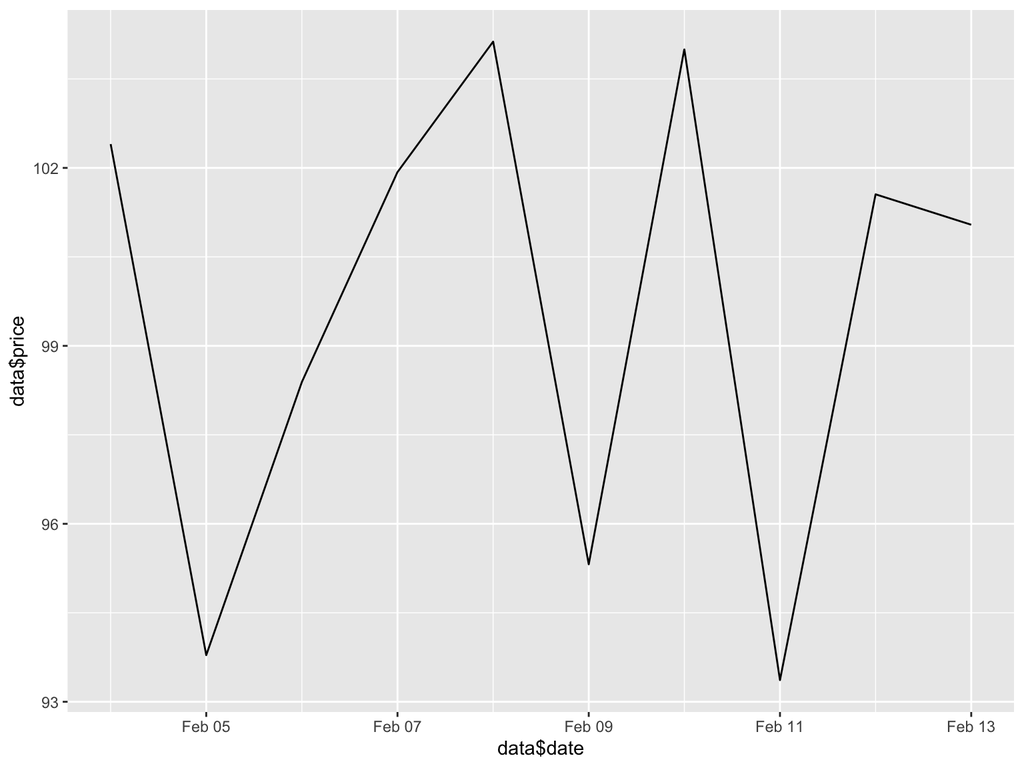

```r
s3$plot()
```

# 17.4.4. Saving and loading `R6` objects

`R6` objects can be saved and loaded just like any other R object.

```r
save(s3, file="foo.rda")
```

Later in a new R session, you can load it back. Below I loading the same `s3` object I saved before.

```r
load("foo.rda")
> s3
<environment: 0x7f9de21509c8>
attr(,"class")
[1] "Stock" "R6"
```

# 17.4.6. Using `R6` in packages.

It is important to document `R6` objects you create properly. Otherwise they are useless.

# 17.4.7. References

`R6` allows for inheritance, active bindings, etc., and this is best described in the vignettes for `R6`. You can also have finalizers for objects. Please refer to the vignettes.

For example, in my package [`ASSISTant`](https://github.com/bnaras/ASSISTant), I use inheritance to define only those methods that differ between different types of design. (See the file `ASSISTDesigns.R` for details.)

There are many other packages you can look at via the *reverse depends* of the `R6` package.